# Homework 5: Unabomber Report (Pro)

Isabel Leiva

February 2026

# Instructions

1. pro css - create a bland but professional style sheet
2. Modify unambomber so you apply pro template
3. Improve your cleaning genie so you’re happy rename the genie first name_genie
4. Summarize your corpus with new cleaning data
5. Write out your hypothesis about unabomber
6. Run your four variables
7. Visualize results
8. Describe the results in human words

# Cleaning Genie

## Loading data and checking structure

```r
#loading unabomber manifesto and printing structure
unabomb <- paste(readLines('https://raw.githubusercontent.com/Reilly-ConceptsCognitionLab/reillylab_publicdata/main/unabomber_manifesto.txt')) # loading in unabomber manifesto
```

## Official Cleaning Genie

```r
#Cleaning Genie function
leiva_genie <- function(x){ #stating the function
   #load stopword and replacement lists from github
   load(url("https://github.com/Reilly-ConceptsCognitionLab/reillylab_publicdata/blob/main/Temple_stops25.rda?raw=true"))
   load(url("https://github.com/Reilly-ConceptsCognitionLab/reillylab_publicdata/blob/main/replacements_25.rda?raw=true"))
   y <- tolower(x) #makes all lower case
   y <- stringi::stri_replace_all_regex(y, "[\u2018\u2019\u02BC\u201B\uFF07\u0092\u0091\u0060\u00B4\u2032\u2035]", "'") #replaces 18 different types of apostrophe with a standard unicode apostrophe
   # Function to replace a word in a target data frame with a replacement word
    replace_words <- function(text, replacements_25) {
     # Replace each bad word with its corresponding good word
     for (i in seq_len(nrow(replacements_25))) {
       text <- gsub(
         pattern = replacements_25$word[i],
         replacement = replacements_25$replacement[i],
         x = text,
         ignore.case = TRUE
       )
     }
     return(text)
    } #note: ONLY works if the apostrophe's between the two dataframes are identical.
   y <- replace_words(y, replacements_25) #replaces contractions with full words
   y <- gsub('[[:punct:]]',' ', y) #removing all punctuation
   y <- gsub("\\b[a-zA-Z]\\b{1}", " ", y) #omits singletons including Aa and Ii
   y <- textstem::lemmatize_strings(y) #lemmatizes text
   y <- gsub('[0-9]+',' ', y) #removing all numbers
   y <- tibble(y) #making into a dataframe for the final piece!
   y <- y %>% unnest_tokens(word, y)  # one word per rows, removing blank spaces, and making all lowercase
   stopwords <- Temple_stops25$word %>% tolower() %>% data.frame(word = .)
   y <- y %>% anti_join(stopwords) #removing stop words by line
   return(y) #final step of the function
}
```

## Deploy Genie: Unabomber

```r
unabomb_clean <- leiva_genie(unabomb) #using the function on unabomber manifesto and saving as new df
unabomb_clean[1:20,] #printing the first 20 lines of the df
```

| word |
| --- |
| industrial |
| society |
| future |
| introduction |
| industrial |
| revolution |
| consequence |
| have |
| disaster |
| human |
| race |
| have |
| greatly |
| increase |
| life |
| expectancy |
| live |
| advance |
| country |
| have |

## Importing unabomber to Quanteda

```r
unabomb_clean_flat <- unabomb_clean %>% summarize(full_text = str_flatten(word, " ")) #using summarise() to create a new df with a row for each combination of grouping variables. Since there are no grouping variable, the output is just a single row with all observations. str_flatten() lets us tell the column being summarized to put a space in between each string.

unabomb_clean_corp <- quanteda::corpus(unabomb_clean_flat, text_field = "full_text") #using the quanteda::corpus() function to convert df into a corpus. The argument text_field() tells quanteda which column of the df to summarize as a corpus.
```

# Corpus summary

This table describes the Types (unique words), Tokens (overall words), Sentences, and type token ratio (TTR; the ratio of unique words compared to the entire text) associated with the text.

```r
docnames(unabomb_clean_corp) <- c("unabomb_clean") #renaming document
unabomb_clean_sum <- summary(unabomb_clean_corp) #summary of cleaned unabomber manifesto
unabomb_clean_token <- quanteda::tokens(unabomb_clean_corp, remove_punct = TRUE) #Create a tokenized version of the clean unabomber corpus for analyses
unabomb_clean_ttrs <- textstat_lexdiv(unabomb_clean_token, measure = c("TTR"), log.base = 10) #lexical diversity, can take a dfm or corpus
unabomb_qualities <- unabomb_clean_sum %>% dplyr::left_join(unabomb_clean_ttrs, by = c("Text" = "document")) #creating lexical characteristics table
print(unabomb_qualities)
```

```
## Corpus consisting of 1 document, showing 1 document:
##
##           Text Types Tokens Sentences       TTR
##  unabomb_clean  2940  19396         1 0.1515776
```

# Unabomber hypotheses

The proposed investigation seeks to conduct a sentiment analysis on The Unabomber Manifesto analyzing the text’s average anger, intensity, valence, and trust. It was hypothesized that the unabomber manifesto would be higher than average in anger and emotional intensity and lower than average in valence and trust.

# Sentiment Analysis

## Loading database and selecting variables

```r
load(url("https://github.com/Reilly-ConceptsCognitionLab/reillylab_publicdata/blob/main/lookup_Jul25.rda?raw=true")) #loading Jamie's lexical lookup database
lookup_db <- lookup_Jul25 #renaming dataframe
lookup_small <- lookup_db %>% dplyr::select(word, emo_anger_rescale, emo_valence_b24_rescale, emo_trust_rescale, emo_intensity_recale) #creating database that suites hypotheses being tested
lookup_small[1:20,] #printing the first 20 lines of the df
```

| word | emo_anger_rescale | emo_valence_b24_rescale | emo_trust_rescale | emo_intensity_recale |
| --- | --- | --- | --- | --- |
| a | 2.58 | 4.51 | 2.75 | 0.11083744 |
| aa | 2.29 | 4.49 | 3.20 | 0.08866995 |
| aaa | 1.87 | NA | 3.47 | NA |
| aaaa | 1.74 | NA | 3.23 | NA |
| aaaaa | 2.29 | NA | 2.76 | NA |
| aaaaaaaaah | 1.94 | NA | 2.71 | NA |
| aaaaaaaah | 2.62 | NA | 2.11 | NA |
| aaaaaaah | 2.81 | 4.60 | 2.35 | 0.28817734 |
| aaaaaah | 2.20 | NA | 2.48 | NA |
| aaaaah | 2.03 | NA | 1.91 | NA |
| aaaaahhh | 2.48 | NA | 1.92 | NA |
| aaaaahhhh | 2.50 | NA | 1.87 | NA |
| aaaaahhhhh | 2.72 | NA | 1.75 | NA |
| aaaaargh | 2.40 | NA | 1.93 | NA |
| aaaagh | 2.85 | NA | 1.87 | NA |
| aaaah | 2.36 | 5.57 | 2.15 | 2.21674877 |
| aaaahh | 2.33 | NA | 1.82 | NA |
| aaaahhh | 1.99 | NA | 1.93 | NA |
| aaaahhhh | 2.31 | NA | 2.32 | NA |
| aaaargh | 3.08 | NA | 1.52 | NA |

# Hypotheses testing

```r
unabomb_analysis <- unabomb_clean %>% dplyr::left_join(lookup_small, by = "word") #joining the manifesto with the sentiment word ratings
unabomb_analysis[1:20,] #printing the first 20 lines of the df
```

| word | emo_anger_rescale | emo_valence_b24_rescale | emo_trust_rescale | emo_intensity_recale |
| --- | --- | --- | --- | --- |
| industrial | 2.52 | 4.52 | 1.85 | 0.1330049 |
| society | 2.46 | 4.58 | 2.92 | 0.2660099 |
| future | 1.19 | 6.86 | 3.70 | 4.7660099 |
| introduction | 1.21 | 4.93 | 3.53 | 0.9532020 |
| industrial | 2.52 | 4.52 | 1.85 | 0.1330049 |
| revolution | 3.31 | 5.70 | 2.01 | 2.4827586 |
| consequence | 2.06 | 4.35 | 2.83 | 0.1852905 |
| have | 2.12 | 4.52 | 3.36 | 0.1330049 |
| disaster | 4.48 | 0.04 | 1.50 | 8.6976058 |
| human | 2.07 | 4.86 | 2.82 | 0.8201970 |
| race | 2.60 | 4.52 | 2.53 | 0.1330049 |
| have | 2.12 | 4.52 | 3.36 | 0.1330049 |
| greatly | 1.90 | 6.59 | 2.53 | 4.2339901 |
| increase | 1.66 | 6.14 | 3.55 | 3.3472906 |
| life | 1.08 | 5.72 | 3.77 | 2.5049261 |
| expectancy | 1.66 | 4.93 | 4.86 | 0.9532020 |
| live | 1.10 | 5.36 | 3.59 | 1.7955665 |
| advance | 1.14 | 6.72 | 3.35 | 4.5000000 |
| country | 2.62 | 4.68 | 2.99 | 0.4655172 |
| have | 2.12 | 4.52 | 3.36 | 0.1330049 |

```r
sapply(unabomb_analysis[,2:5], mean, na.rm = TRUE) #calculating the means of the unabomber analysis
```

```
##       emo_anger_rescale emo_valence_b24_rescale       emo_trust_rescale
##                2.257821                4.770153                2.943941
##    emo_intensity_recale
##                1.605273
```

```r
sapply(unabomb_analysis[,2:5], sd, na.rm = TRUE) #calculating the standard deviation of the unabomber analysis
```

```
##       emo_anger_rescale emo_valence_b24_rescale       emo_trust_rescale
##               0.7282514               1.3547893               0.7480325
##    emo_intensity_recale
##               2.2340980
```

# Visualize results

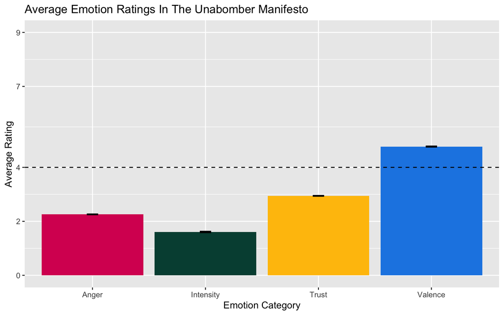

```r
#rearranging data for visualization
df_ggplot <- unabomb_analysis %>%
  dplyr::select(word, emo_anger_rescale, emo_valence_b24_rescale, emo_trust_rescale, emo_intensity_recale) %>% # selecting which columns to keep
  pivot_longer(cols = starts_with("emo"), names_to = "emotion", values_to = "rating") #pairing each column with its value vertically.

#bar plot of emotion
ggplot(df_ggplot, aes(x = emotion, y = rating, fill = emotion)) + #specifying variables for each axis
  geom_bar(position = "dodge", stat = "summary") + #specifying statistical analysis for bar graph (defaults to mean/sd)
  geom_errorbar(stat="summary",position=position_dodge(.55), width=0.1, size=.8) + #creating an error bar
  geom_hline(yintercept=4, linetype = "dashed") + #creating a line to indicate the "average"
  scale_fill_manual(values = c('emo_anger_rescale' = '#D81B60', 'emo_valence_b24_rescale' = '#1E88E5', 'emo_trust_rescale' = '#FFC107', 'emo_intensity_recale' = '#004D40')) + #specifying what color represents each variable
  scale_x_discrete(labels=c('Anger', 'Intensity', 'Trust', 'Valence')) + #creating clearer names for each variable
  theme(legend.position = "none") + #removing legend
  scale_y_continuous(limits=c(0,9), breaks=c(0, 2, 4, 7, 9)) + #specifying y-axis limits
  labs (title = 'Average Emotion Ratings In The Unabomber Manifesto',
        x = 'Emotion Category',
        y = 'Average Rating') #creating labels for each part of the graph
```

# Results

It was hypothesized that The Unabomber Manifesto would be higher than average in anger and emotional intensity and lower than average in valence and trust, with an average sentiment value being 4 in the dataset. The Unabomber Manifesto was indeed found to be lower than average in trust (M = 2.94; SD = 0.75. However, it in actuality lower than average in anger (M = 2.26, SD = 0.73) and intensity (M = 1.61; SD = 2.23), and higher than average in valence (M = 4.77; SD = 1.35).